# Cyclistic_Full_Analysis

### Bike and user analysis

The marketing value of the company is that it offers a range of products to make bike-share more inclusive to people with disabilities and riders who can’t use a standard two-wheeled bike. Cyclistic sets itself apart by offering classic, docked and electric bikes. From the analysis, it is observed that docked bikes are the most utilized bikes,accouting for 57.38% of bike use, used 2,331,368 times, far outpacing the other two bike categories. The classic bike was accounts for 20.76%, used 843,579 times and electric bikes used 888,278 times at 21.86%.

```r
all_trips_v2 %>%
  group_by(rideable_type) %>%
  summarise(number_of_rides = n())
```

```
## # A tibble: 3 × 2
##   rideable_type number_of_rides
##   <chr>                   <int>
## 1 classic_bike           843579
## 2 docked_bike           2331368
## 3 electric_bike          888278
```

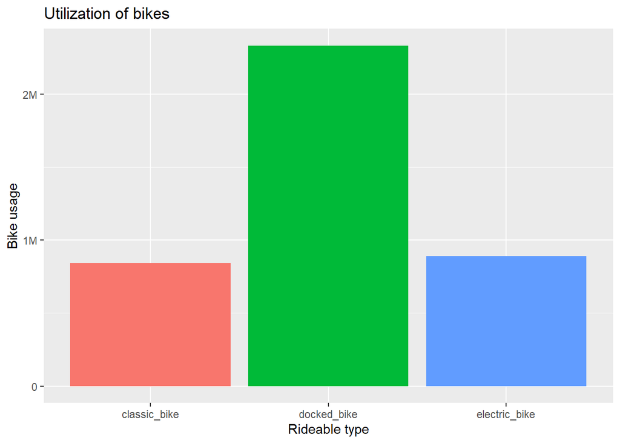

```r
all_trips_v2 %>%
  group_by(rideable_type) %>%
  summarise(number_of_rides = n()) %>%
  ggplot(aes(rideable_type, number_of_rides, fill = rideable_type)) +
  geom_col(position = "dodge", show.legend = FALSE) +
  scale_y_continuous(labels = scales::label_number_si(),
                     breaks = seq(0, 3000000, 1000000)) +
  labs(title = "Utilization of bikes",
       x = "Rideable type",
       y = "Bike usage")
```

The data further reveals that the annual members utilized the bikes more than their casual counterparts across all the rideable bike types. The data is aggregated across all the months between June 2020 and May 2021. The docked bike had a total of 1,071,021 casual rides and 1,260,347 rides by annual members. Compared to 514,641 electric rides by annual members and 373,637 by casuals. The classic bike appears to be the least used rideable bike type with 265,526 rides by casuals and 578,053 by members.

```r
all_trips_v2 %>%
  group_by(member_casual, rideable_type) %>%
  summarise(number_of_rides = n(),
            .groups = "drop") %>%
  arrange(rideable_type)
```

```
## # A tibble: 6 × 3
##   member_casual rideable_type number_of_rides
##   <chr>         <chr>                   <int>
## 1 casual        classic_bike           265526
## 2 member        classic_bike           578053
## 3 casual        docked_bike           1071021
## 4 member        docked_bike           1260347
## 5 casual        electric_bike          373637
## 6 member        electric_bike          514641
```

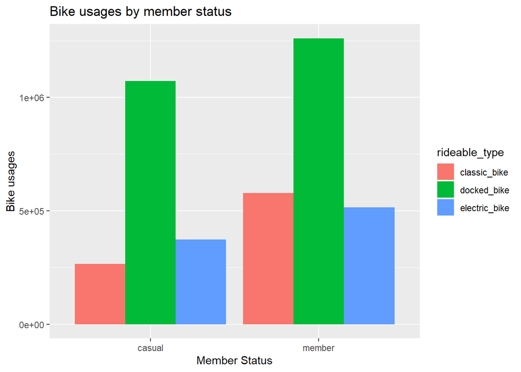

```r
all_trips_v2 %>%
  group_by(member_casual, rideable_type) %>%
  summarise(number_of_rides = n(),
            .groups = "drop") %>%
  ggplot(aes(member_casual, number_of_rides, fill = rideable_type)) +
  geom_col(position = "dodge") +
  labs(title = "Bike usages by member status",
       x = "Member Status",
       y = "Bike usages")
```

In addition to being the most used rideable bike type, the docked bike also recorded the highest average trip duration across the bike categories. The average trip duration by all riders for the docked rideable type was 33 minutes, 20 minutes for the classic bike and 16 minutes for the electric rideable type.

```r
# bike type and average ride length
all_trips_v2 %>%
  group_by(rideable_type) %>%
  summarise(mean = mean(ride_length),
            .groups = "drop") %>%
  arrange(rideable_type)
```

```
## # A tibble: 3 × 2
##   rideable_type  mean
##   <chr>         <dbl>
## 1 classic_bike  1209.
## 2 docked_bike   1994.
## 3 electric_bike 1015.
```

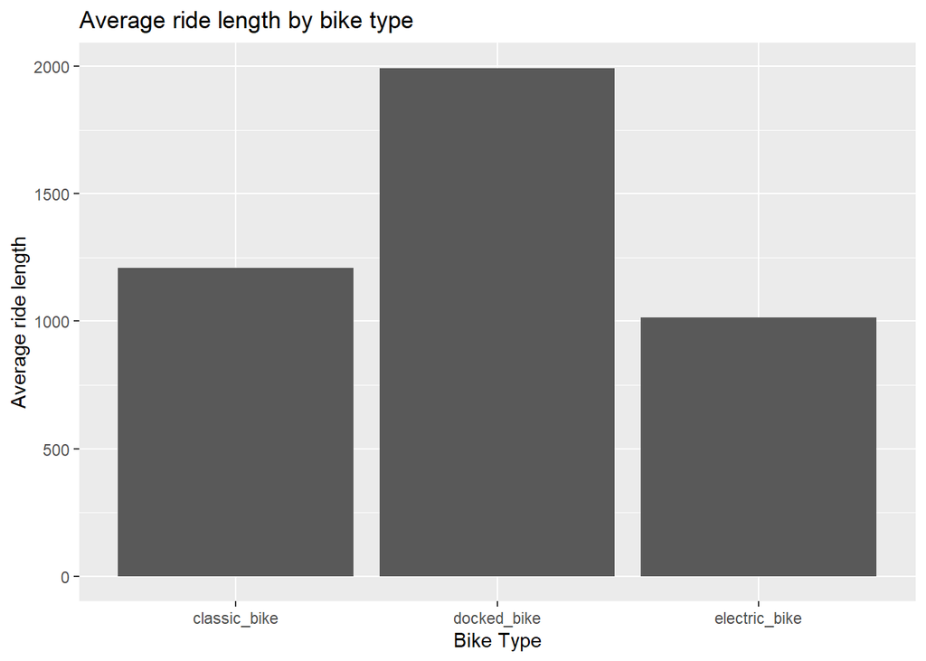

```r
all_trips_v2 %>%
  group_by(rideable_type) %>%
  summarise(mean = mean(ride_length),
            .groups = "drop") %>%
  ggplot(aes(rideable_type, mean)) +
  geom_col(position = "dodge") +
  labs(title = "Average ride length by bike type",
       y = "Average ride length",
       x = "Bike Type")
```

```r
all_trips %>%
  group_by(member_casual, rideable_type) %>%
  summarise(mean = mean(ride_length),
            .groups = "drop") %>%
  arrange(rideable_type)
```

```
## # A tibble: 6 × 3
##   member_casual rideable_type  mean
##   <chr>         <chr>         <dbl>
## 1 casual        classic_bike  1915.
## 2 member        classic_bike   885.
## 3 casual        docked_bike   3114.
## 4 member        docked_bike    746.
## 5 casual        electric_bike 1051.
## 6 member        electric_bike  425.
```

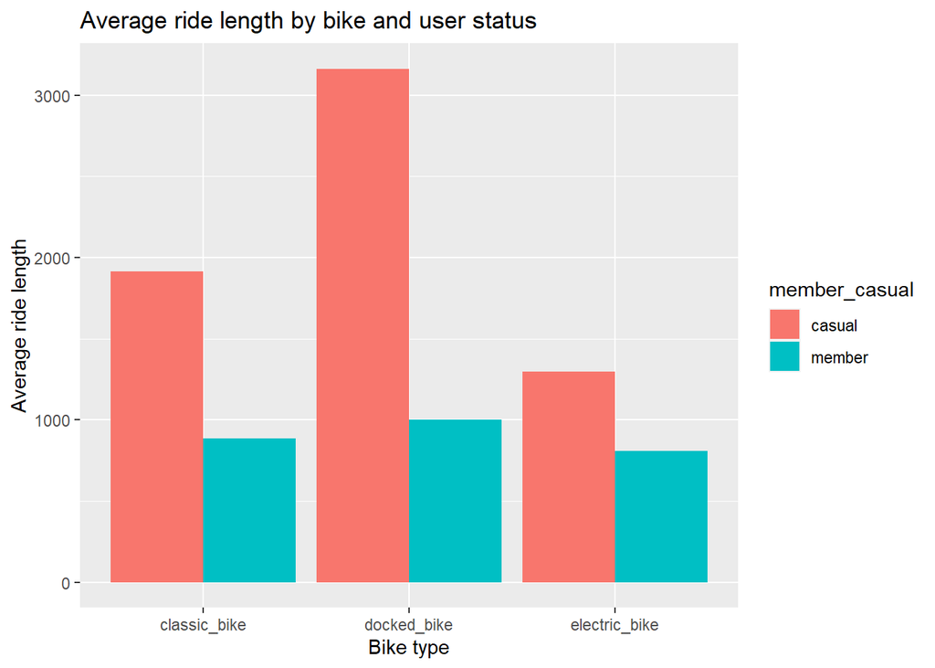

```r
all_trips_v2 %>%
  group_by(member_casual, rideable_type) %>%
  summarise(mean = mean(ride_length),
            .groups = "drop") %>%
  ggplot(aes(rideable_type, mean, fill = member_casual)) +
  geom_col(position = "dodge") +
  labs(title = "Average ride length by bike and user status",
       y = "Average ride length",
       x = "Bike type")
```